# Bellabeat Case Study Report

Shuang Li

2025-03-31

## Scope of Work

### Data Analyst:

Shuang Li

### Client:

Bellabeat

### Purpose:

The goal of this project is to analyze smart device usage data in order to gain insight into how consumers use non-Bellabeat smart devices. The project will discover how these trends apply to Bellabeat customers and how these trends help influence Bellabeat marketing strategy.

### Scope / Major Project Activities:

| Activity | Description |
| --- | --- |
| Collect data | Collect public Fitbit fitness tracker data from Kaggle |
| Identify trends | Identify trends in smart device usage |
| Visualize findings | visualize key findings in trends |
| Create marketing recommendations | Create marketing strategy recommendations based on these trends |
| Deliver final report | Deliver final report and recommendations to key stakeholders |

### Deliverables:

- A clear summary of the business task
- A description of all data sources used
- Documentation of any cleaning or manipulation of data
- A summary of the analysis
- Supporting visualizations and key findings
- Top high-level content recommendations based on the analysis

### This project does not include:

- Collecting and/or analyzing user demographics data;
- Collecting and/or analyzing workout type and session duration data;
- Projecting seasonal changes;
- Implementing any solutions or recommendations.

### Schedule Overview / Major Milestones:

| Milestone | Expected Completion Date | Description/Details |
| --- | --- | --- |
| Data Review | 2025-03-25 | Review of all data |
| Data Cleaning and Analysis | 2025-03-27 | Initial data analysis completed |
| Identify Trends | 2025-03-28 | Top trends identified |
| Create Visualization | 2025-03-29 | Visualization created |
| Make Tailored Recommendation | 2025-03-30 | List of marketing strategy recommendations |
| Final Report | 2025-03-31 | Final report detailing all work |

### Estimated date for completion:

2025-03-31

## Prepare and Understand the Dataset

1. Download the [FitBit Fitness Tracker Data](https://www.kaggle.com/datasets/arashnic/fitbit/data) (CC0: Public Domain, dataset made available through [Mobius](https://www.kaggle.com/arashnic)).
2. Import the dataset into RStudio and rename identical dataset names by adding the month in which the data was collected.

```r
library(tidyverse)
march_dailyActivity_merged <- read.csv("mturkfitbit_export_march/dailyActivity_merged.csv")
march_heartrate_seconds_merged <- read.csv("mturkfitbit_export_march/heartrate_seconds_merged.csv")
march_minuteIntensitiesNarrow_merged <- read.csv("mturkfitbit_export_march/minuteIntensitiesNarrow_merged.csv")
march_minuteSleep_merged <- read.csv("mturkfitbit_export_march/minuteSleep_merged.csv")
march_weightLogInfo_merged <- read.csv("mturkfitbit_export_march/weightLogInfo_merged.csv")
april_dailyActivity_merged <- read.csv("mturkfitbit_export_april/dailyActivity_merged.csv")
april_heartrate_seconds_merged <- read.csv("mturkfitbit_export_april/heartrate_seconds_merged.csv")
april_minuteIntensitiesNarrow_merged <- read.csv("mturkfitbit_export_april/minuteIntensitiesNarrow_merged.csv")
april_minuteSleep_merged <- read.csv("mturkfitbit_export_april/minuteSleep_merged.csv")
april_weightLogInfo_merged <- read.csv("mturkfitbit_export_april/weightLogInfo_merged.csv")
```

3. Review the metrics of the data collected, identify its components and limitations in order to determine the approaches to answering the business questions.
- data was categoried into daily/hourly/minute records;
- metrics presented: Distance, Steps, Calories, Active Minutes, Intensity Level, Heart Rate, Sleep, Weight.
4. Determine the credibility of the data.

## Process and Analyze the Data

### ➤ Find frequency of device usage

1. Identify the master sheet from each month and ‘count’ the number of days each user used the fitness tracker per month.

```r
march_activity_record <- march_dailyActivity_merged %>%
group_by(Id) %>%
summarise(non_null_count = sum(!is.na(ActivityDate)))
glimpse(march_activity_record)
```

```
## Rows: 35
## Columns: 2
## $ Id             <dbl> 1503960366, 1624580081, 1644430081, 1844505072, 1927972…
## $ non_null_count <int> 19, 19, 10, 12, 12, 12, 12, 12, 15, 12, 8, 10, 12, 32, …
```

```r
april_activity_record <- april_dailyActivity_merged %>%
group_by(Id) %>%
summarise(non_null_count = sum(!is.na(ActivityDate)))
glimpse(april_activity_record)
```

```
## Rows: 33
## Columns: 2
## $ Id             <dbl> 1503960366, 1624580081, 1644430081, 1844505072, 1927972…
## $ non_null_count <int> 31, 31, 30, 31, 31, 31, 31, 31, 18, 31, 20, 30, 31, 4, …
```

2. Crosscheck the user ID in both tables to verify if the sample group from both month are the same.

```r
matching_count <- march_activity_record %>%
inner_join(april_activity_record, by = "Id") %>%
nrow()
print(matching_count)
```

```
## [1] 33
```

3. Inner join the two tables to get a dataset of frequency of device usage for future analysis.

```r
joined_activity_days <- march_activity_record %>% inner_join(april_activity_record, by = "Id")
glimpse(joined_activity_days)
```

```
## Rows: 33
## Columns: 3
## $ Id               <dbl> 1503960366, 1624580081, 1644430081, 1844505072, 19279…
## $ non_null_count.x <int> 19, 19, 10, 12, 12, 12, 12, 12, 15, 12, 10, 12, 32, 3…
## $ non_null_count.y <int> 31, 31, 30, 31, 31, 31, 31, 31, 18, 31, 20, 30, 31, 4…
```

4. Find average usage per month.

```r
average_usage <- joined_activity_days %>% rowwise() %>% mutate(usage_per_month = mean(c(non_null_count.x,non_null_count.y)))
glimpse(average_usage)
```

```
## Rows: 33
## Columns: 4
## Rowwise:
## $ Id               <dbl> 1503960366, 1624580081, 1644430081, 1844505072, 19279…
## $ non_null_count.x <int> 19, 19, 10, 12, 12, 12, 12, 12, 15, 12, 10, 12, 32, 3…
## $ non_null_count.y <int> 31, 31, 30, 31, 31, 31, 31, 31, 18, 31, 20, 30, 31, 4…
## $ usage_per_month  <dbl> 25.0, 25.0, 20.0, 21.5, 21.5, 21.5, 21.5, 21.5, 16.5,…
```

### ➤ Identify core user groups by fitness level

1. In the same two master sheets, group users by ID and add FairlyaActiveMinutes and 2x VeryActiveMinutes to find the totoal active minutes per user per month.

```r
march_active_minutes <- march_dailyActivity_merged %>% group_by(Id) %>% summarise(total_active_minutes = sum(very_active_minutes_2 = (2*VeryActiveMinutes), FairlyActiveMinutes))
glimpse(march_active_minutes)
```

```
## Rows: 35
## Columns: 2
## $ Id                   <dbl> 1503960366, 1624580081, 1644430081, 1844505072, 1…
## $ total_active_minutes <dbl> 1663, 39, 731, 27, 20, 1232, 0, 35, 701, 194, 660…
```

```r
april_active_minutes <- april_dailyActivity_merged %>% group_by(Id) %>% summarise(total_active_minutes = sum(very_active_minutes_2 = (2*VeryActiveMinutes), FairlyActiveMinutes))
glimpse(april_active_minutes)
```

```
## Rows: 33
## Columns: 2
## $ Id                   <dbl> 1503960366, 1624580081, 1644430081, 1844505072, 1…
## $ total_active_minutes <dbl> 2994, 718, 1215, 48, 106, 2850, 14, 164, 856, 106…
```

2. Find out the weekly average active minutes per user.

```r
weekly_active_minutes <- march_active_minutes %>% inner_join(april_active_minutes, by = "Id") %>% mutate(weekly_active_minutes = as.integer(round(total_active_minutes.x + total_active_minutes.y)/62*7))
glimpse(weekly_active_minutes)
```

```
## Rows: 33
## Columns: 4
## $ Id                     <dbl> 1503960366, 1624580081, 1644430081, 1844505072,…
## $ total_active_minutes.x <dbl> 1663, 39, 731, 27, 20, 1232, 0, 35, 701, 194, 2…
## $ total_active_minutes.y <dbl> 2994, 718, 1215, 48, 106, 2850, 14, 164, 856, 1…
## $ weekly_active_minutes  <int> 525, 85, 219, 8, 14, 460, 1, 22, 175, 142, 81, …
```

3. Categorize user fitness level into Beginner, Intermediate, and Advanced

```r
weekly_active_minutes <- weekly_active_minutes %>% mutate(fitness_level = case_when(
      weekly_active_minutes < 150 ~ "Beginner",
      weekly_active_minutes >= 150 & weekly_active_minutes < 300 ~ "Intermediate",
      weekly_active_minutes >= 300 ~ "Advanced"
    ))
glimpse(weekly_active_minutes)
```

```
## Rows: 33
## Columns: 5
## $ Id                     <dbl> 1503960366, 1624580081, 1644430081, 1844505072,…
## $ total_active_minutes.x <dbl> 1663, 39, 731, 27, 20, 1232, 0, 35, 701, 194, 2…
## $ total_active_minutes.y <dbl> 2994, 718, 1215, 48, 106, 2850, 14, 164, 856, 1…
## $ weekly_active_minutes  <int> 525, 85, 219, 8, 14, 460, 1, 22, 175, 142, 81, …
## $ fitness_level          <chr> "Advanced", "Beginner", "Intermediate", "Beginn…
```

4. Count number of users in each category

```r
user_fitness_levels <- weekly_active_minutes %>% count(fitness_level)
glimpse(user_fitness_levels)
```

```
## Rows: 3
## Columns: 2
## $ fitness_level <chr> "Advanced", "Beginner", "Intermediate"
## $ n             <int> 10, 17, 6
```

### ➤ Key features usage

1. Review data collected from different features and make note that core features like Distance, Steps, Intensity Minutes, and Calories are automatically being tracked. Identify other key features that are being frequently used are Heart Rate, Sleep, and Weight Log.
2. Count number of users used each feature in each month.

```r
n_distinct(march_heartrate_seconds_merged$Id)
```

```
## [1] 14
```

```r
n_distinct(march_minuteSleep_merged$Id)
```

```
## [1] 23
```

```r
n_distinct(march_weightLogInfo_merged$Id)
```

```
## [1] 11
```

```r
n_distinct(april_heartrate_seconds_merged$Id)
```

```
## [1] 14
```

```r
n_distinct(april_minuteSleep_merged$Id)
```

```
## [1] 24
```

```r
n_distinct(april_weightLogInfo_merged$Id)
```

```
## [1] 8
```

```r
feature_usage <- tibble(
key_feature = c("Sleep Tracking","Heart Rate Monitor","Weight Log"),
March = c(n_distinct(march_heartrate_seconds_merged$Id), n_distinct(march_minuteSleep_merged$Id), n_distinct(march_weightLogInfo_merged$Id)),
April = c(n_distinct(april_heartrate_seconds_merged$Id), n_distinct(april_minuteSleep_merged$Id), n_distinct(april_weightLogInfo_merged$Id))
) %>%
  mutate(
    march_percentage = round(March/ 35 * 100, 1),
    april_percentage = round(April/ 33 * 100, 1)
      )
glimpse(feature_usage)
```

[output not shown]

### ➤ Find time of day users are more active

1. Figure out how the intensity is classified.

```r
n_distinct(march_minuteIntensitiesNarrow_merged$Intensity)
```

```
## [1] 4
```

2. Found out that the intensity is being rated from 0 to 3, in which 0 being sedentary and 3 being vigorous. Therefore, identify the time of day when 3 appeared.

```r
march_high_intensity_time <- march_minuteIntensitiesNarrow_merged %>% filter(Intensity == 3)
glimpse(march_high_intensity_time)
```

```
## Rows: 19,098
## Columns: 3
## $ Id             <dbl> 1503960366, 1503960366, 1503960366, 1503960366, 1503960…
## $ ActivityMinute <chr> "3/12/2016 10:59:00 AM", "3/12/2016 11:00:00 AM", "3/12…
## $ Intensity      <int> 3, 3, 3, 3, 3, 3, 3, 3, 3, 3, 3, 3, 3, 3, 3, 3, 3, 3, 3…
```

```r
april_high_intensity_time <- april_minuteIntensitiesNarrow_merged %>% filter(Intensity == 3)
glimpse(april_high_intensity_time)
```

```
## Rows: 19,838
## Columns: 3
## $ Id             <dbl> 1503960366, 1503960366, 1503960366, 1503960366, 1503960…
## $ ActivityMinute <chr> "4/12/2016 2:51:00 PM", "4/12/2016 2:52:00 PM", "4/12/2…
## $ Intensity      <int> 3, 3, 3, 3, 3, 3, 3, 3, 3, 3, 3, 3, 3, 3, 3, 3, 3, 3, 3…
```

3. Split the datetime and only keep the hour.

```r
march_high_intensity_time <- march_high_intensity_time %>%
  mutate(
    datetime_parsed = mdy_hms(ActivityMinute),    # Parse character to POSIXct
    date_only = as.Date(datetime_parsed),         # Extract Date
    hour_only = hour(datetime_parsed)             # Extract Hour (24-hour format)
   ) %>%
select(-datetime_parsed)
glimpse(march_high_intensity_time)
```

```
## Rows: 19,098
## Columns: 5
## $ Id             <dbl> 1503960366, 1503960366, 1503960366, 1503960366, 1503960…
## $ ActivityMinute <chr> "3/12/2016 10:59:00 AM", "3/12/2016 11:00:00 AM", "3/12…
## $ Intensity      <int> 3, 3, 3, 3, 3, 3, 3, 3, 3, 3, 3, 3, 3, 3, 3, 3, 3, 3, 3…
## $ date_only      <date> 2016-03-12, 2016-03-12, 2016-03-12, 2016-03-12, 2016-0…
## $ hour_only      <int> 10, 11, 11, 11, 11, 11, 11, 11, 11, 11, 11, 11, 12, 12,…
```

```r
april_high_intensity_time <- april_high_intensity_time %>%
  mutate(
    datetime_parsed = mdy_hms(ActivityMinute),    # Parse character to POSIXct
    date_only = as.Date(datetime_parsed),         # Extract Date
    hour_only = hour(datetime_parsed)             # Extract Hour (24-hour format)
   ) %>%
select(-datetime_parsed)
glimpse(april_high_intensity_time)
```

```
## Rows: 19,838
## Columns: 5
## $ Id             <dbl> 1503960366, 1503960366, 1503960366, 1503960366, 1503960…
## $ ActivityMinute <chr> "4/12/2016 2:51:00 PM", "4/12/2016 2:52:00 PM", "4/12/2…
## $ Intensity      <int> 3, 3, 3, 3, 3, 3, 3, 3, 3, 3, 3, 3, 3, 3, 3, 3, 3, 3, 3…
## $ date_only      <date> 2016-04-12, 2016-04-12, 2016-04-12, 2016-04-12, 2016-0…
## $ hour_only      <int> 14, 14, 14, 14, 14, 15, 15, 15, 15, 15, 15, 15, 15, 15,…
```

4. Remove duplicate records (same user, same date and hour)

```r
march_high_intensity_time <- march_high_intensity_time %>% select(-ActivityMinute, -Intensity) %>% group_by(Id, date_only, hour_only) %>% distinct()
glimpse(march_high_intensity_time)
```

```
## Rows: 1,348
## Columns: 3
## Groups: Id, date_only, hour_only [1,348]
## $ Id        <dbl> 1503960366, 1503960366, 1503960366, 1503960366, 1503960366, …
## $ date_only <date> 2016-03-12, 2016-03-12, 2016-03-12, 2016-03-12, 2016-03-12,…
## $ hour_only <int> 10, 11, 12, 14, 15, 16, 10, 11, 18, 19, 23, 9, 23, 9, 12, 20…
```

```r
april_high_intensity_time <- april_high_intensity_time %>% select(-ActivityMinute, -Intensity) %>% group_by(Id, date_only, hour_only) %>% distinct()
glimpse(april_high_intensity_time)
```

```
## Rows: 1,374
## Columns: 3
## Groups: Id, date_only, hour_only [1,374]
## $ Id        <dbl> 1503960366, 1503960366, 1503960366, 1503960366, 1503960366, …
## $ date_only <date> 2016-04-12, 2016-04-12, 2016-04-12, 2016-04-13, 2016-04-13,…
## $ hour_only <int> 14, 15, 20, 14, 17, 18, 23, 13, 20, 21, 17, 22, 23, 12, 13, …
```

5. Count number of each hour appeared

```r
march_time_count <- march_high_intensity_time %>% ungroup() %>% count(hour_only)
glimpse(march_time_count)
```

```
## Rows: 23
## Columns: 2
## $ hour_only <int> 0, 1, 3, 4, 5, 6, 7, 8, 9, 10, 11, 12, 13, 14, 15, 16, 17, 1…
## $ n         <int> 7, 3, 1, 1, 21, 28, 50, 66, 82, 86, 94, 94, 89, 93, 55, 73, …
```

```r
april_time_count <- april_high_intensity_time %>% ungroup() %>% count(hour_only)
glimpse(april_time_count)
```

```
## Rows: 22
## Columns: 2
## $ hour_only <int> 0, 1, 2, 5, 6, 7, 8, 9, 10, 11, 12, 13, 14, 15, 16, 17, 18, …
## $ n         <int> 7, 4, 2, 31, 41, 50, 83, 70, 85, 78, 105, 94, 101, 55, 63, 1…
```

6. Full join the two tables and add counts together

```r
total_time_count <- march_time_count %>% full_join(april_time_count, by = "hour_only") %>% mutate(across(everything(), ~replace_na(., 0))) %>% rowwise() %>% mutate(total_count = sum(n.x, n.y))
glimpse(total_time_count)
```

```
## Rows: 24
## Columns: 4
## Rowwise:
## $ hour_only   <int> 0, 1, 3, 4, 5, 6, 7, 8, 9, 10, 11, 12, 13, 14, 15, 16, 17,…
## $ n.x         <int> 7, 3, 1, 1, 21, 28, 50, 66, 82, 86, 94, 94, 89, 93, 55, 73…
## $ n.y         <int> 7, 4, 0, 0, 31, 41, 50, 83, 70, 85, 78, 105, 94, 101, 55, …
## $ total_count <int> 14, 7, 1, 1, 52, 69, 100, 149, 152, 171, 172, 199, 183, 19…
```

## Visualize and Share Findings

### Trend 1: User Segmentation

🔍 **Discover user fitness levels and identify core user groups.**

The active minutes requirements for different fitness levels (Beginner, Intermediate, and Advanced) are based on guidelines from WHO, CDC, and ACSM (American College of Sports Medicine), as well as fitness tracker classifications.

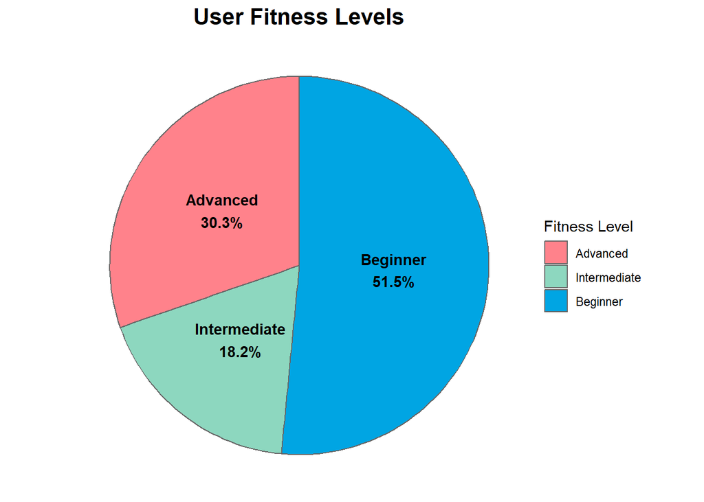

```r
# Add percentage and label
user_fitness_levels <- user_fitness_levels %>%
  mutate(
    Category = factor(fitness_level, levels = c("Advanced", "Intermediate", "Beginner")),
    Percent = n / sum(n) * 100,
    Label = paste0(fitness_level, "\n", round(Percent, 1), "%")
  ) %>%
  arrange(Category)

# Custom color mapping
custom_colors <- c(
  "Beginner" = "#00A5E3",
  "Intermediate" = "#8DD7BF",
  "Advanced" = "#FF828B"
)

# Pie chart with proper color assignment
ggplot(user_fitness_levels, aes(x = "", y = n, fill = Category)) +
  geom_bar(stat = "identity", width = 1, color = "grey40") +
  coord_polar(theta = "y") +
  geom_text(aes(label = Label), fontface = "bold", position = position_stack(vjust = 0.5)) +
  scale_fill_manual(values = custom_colors) +
  labs(title = "User Fitness Levels", fill = "Fitness Level") +
  theme_void() +
  theme(plot.title = element_text(hjust = 0.5, face = "bold", size = 16))
```

### Trend 2: Device Usage Patterns

🔍 **Discover frequency of device usage per week**

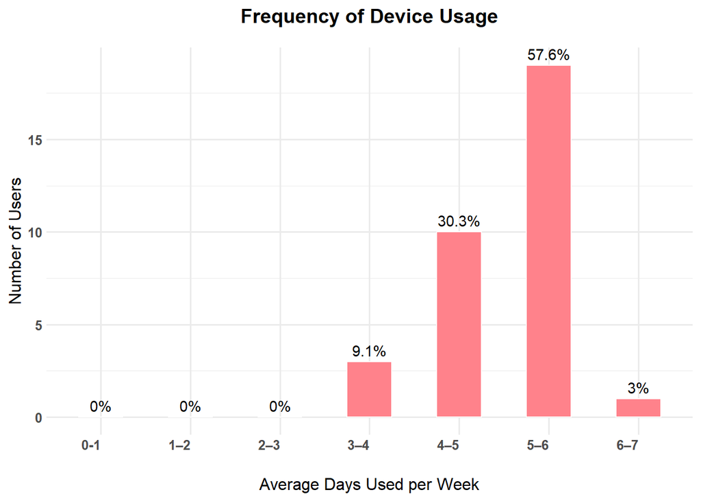

```r
# Categorize into usage buckets
average_usage <- average_usage %>%
  mutate(usage_category = case_when(
    usage_per_month >= 0  & usage_per_month < 5  ~ "0-1",
    usage_per_month >= 5  & usage_per_month < 9  ~ "1–2",
    usage_per_month >= 9  & usage_per_month < 13 ~ "2–3",
    usage_per_month >= 13 & usage_per_month < 17 ~ "3–4",
    usage_per_month >= 17 & usage_per_month < 21 ~ "4–5",
    usage_per_month >= 21 & usage_per_month < 27 ~ "5–6",
    usage_per_month >= 27 & usage_per_month < 32 ~ "6–7",
    TRUE ~ NA_character_  # fallback for unexpected values
  ))

# Factor for correct order in plotting
average_usage$usage_category <- factor(average_usage$usage_category, levels = c(
  "0-1",
  "1–2",
  "2–3",
  "3–4",
  "4–5",
  "5–6",
  "6–7"
))
usage_summary <- average_usage %>%
  count(usage_category) %>%
  complete(usage_category, fill = list(n = 0)) %>%
  mutate(percent = n / sum(n) * 100)

# Create Histogram-Style Bar Chart for Categorized Usage
ggplot(usage_summary, aes(x = usage_category, y = n)) +
  geom_col(fill = "#FF828B", color = "white", width = 0.5) +
  geom_text(aes(label = paste0(round(percent, 1), "%")),
            vjust = -0.5) +
  labs(
    title = "Frequency of Device Usage",
    x = "Average Days Used per Week",
    y = "Number of Users"
  ) +
  theme_minimal(base_size = 12) +
  theme(
    plot.title = element_text(hjust = 0.5, face = "bold", margin = margin(b = 15)),
    axis.text.x = element_text(hjust = 1, face = "bold",margin = margin(b = 15)),
    axis.text.y = element_text(hjust = 1, face = "bold", margin = margin(b = 15))
  )
```

### Trend 3: Key Features Usage

🔍 **Discover percentage of key features used**

[figure not shown]

```r
# Actual user totals per month (manually defined)
user_totals <- tibble(
  Month = c("March", "April"),
  total_users = c(35, 33)
)
# Reshape for plotting
feature_usage_long <- feature_usage %>%
  pivot_longer(cols = c(March, April), names_to = "Month", values_to = "count") %>%
  left_join(user_totals, by = "Month") %>%
  mutate(
    Month = factor(Month, levels = c("March", "April")),
    percent = count / total_users * 100,
    label = paste0(round(percent, 1), "%")
  )
feature_usage_long <- feature_usage_long %>%
  group_by(key_feature) %>%
  mutate(total = sum(count)) %>%
  ungroup() %>%
  mutate(key_feature = fct_reorder(key_feature, total))

# Custom color mapping
custom_colors <- c(
  "March" = "#FF828B",
  "April" = "#00A5E3"
)
bar_width <- 0.25  # make bars thinner for spacing
dodge_width <- 0.6  # slightly more than bar width

ggplot(feature_usage_long, aes(x = count, y = key_feature, fill = Month)) +
  geom_col(
    position = position_dodge2(width = dodge_width, reverse = TRUE),
    width = bar_width
  ) +
  geom_text(
    aes(label = label),
    position = position_dodge2(width = dodge_width, reverse = TRUE),
    hjust = -0.1,
  ) +
  labs(
    title = "Feature Usage by Month",
    x = "User Count",
    y = "Key Feature",
    fill = "Month"
  ) +
  scale_fill_manual(values = custom_colors) +
  theme_minimal(base_size = 12) +
  theme(
    plot.title = element_text(hjust = 0.5, face = "bold", margin = margin(b = 15)),
    axis.text.x = element_text(hjust = 1, face = "bold"),
    axis.text.y = element_text(hjust = 1, face = "bold")
  ) +
  xlim(0, max(feature_usage_long$count) * 1.3)
```

### Trend 4: Device Engagement Patterns

🔍 **Discover time of day users engage the most**

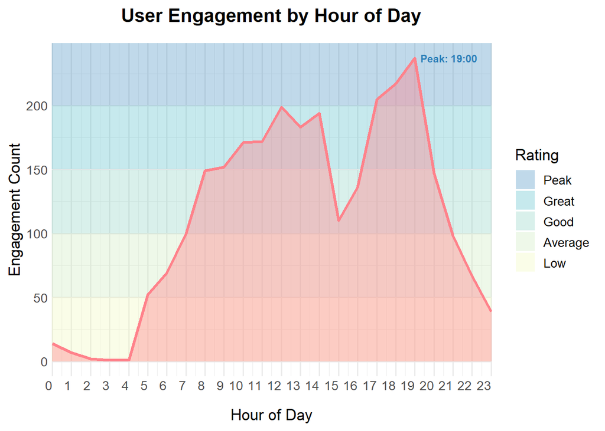

```r
# Define tiers as horizontal bands (ymin to ymax)
tier_bands <- tibble(
  tier = factor(c("Peak", "Great", "Good", "Average", "Low"),
                levels = c("Peak", "Great", "Good", "Average", "Low")),
  ymin = c(200, 150, 100, 50, 0),
  ymax = c(Inf, 199.9, 149.9, 99.9, 49.9)
)

# Assign colors to each tier
tier_colors <- c(
  "Peak"    = "#2C7FB8",  # Deep blue
  "Great"   = "#41B6C4",  # Teal
  "Good"    = "#7FCDBB",  # Soft mint
  "Average" = "#C7E9B4",  # Pale green
  "Low"     = "#EDF8B1"   # Very light green-yellow
)

peak_point <- total_time_count %>% ungroup() %>% filter(total_count == max(total_count))

# Plot
ggplot() +
  # Tier background bands
  geom_rect(
    data = tier_bands,
    aes(ymin = ymin, ymax = ymax, xmin = -Inf, xmax = Inf, fill = tier),
    alpha = 0.3
  ) +
  # Area + line on top
  geom_area(data = total_time_count, aes(x = hour_only, y = total_count), fill = "#FF828B", alpha = 0.4) +
  geom_line(data = total_time_count, aes(x = hour_only, y = total_count), color = "#FF828B", size = 1.2) +

  scale_x_continuous(breaks = 0:23, expand = c(0, 0)) +
  scale_fill_manual(values = tier_colors, name = "Rating") +
  labs(
    title = "User Engagement by Hour of Day",
    x = "Hour of Day",
    y = "Engagement Count"
  ) +
  geom_text(
  data = peak_point,
  mapping = aes(
    x = hour_only + 0.3,  # 👈 shifts label slightly to the right
    y = total_count,
    label = paste0("Peak: ", hour_only, ":00")
  ),
  hjust = 0,  # left-align the text
  vjust = 0.5,
  fontface = "bold",
  color = "#2C7FB8",
  size = 3,
  inherit.aes = FALSE
) +
  theme_minimal(base_size = 13) +
  theme(
    plot.title = element_text(hjust = 0.5, face = "bold", margin = margin(b = 15)),
    legend.position = "right",
    axis.text.x = element_text(hjust = 1, margin = margin(b = 10)),
    axis.text.y = element_text(hjust = 1, margin = margin(b = 10))
  )
```

## Marketing Strategy Recommendations for Bellabeat Ivy+

### 1. Segment by Fitness Level — With a Wellness Twist

| Fitness Group | Bellabeat Approach |
| --- | --- |
| **Beginner (51.5%)** | Focus on gentle wellness, cycle-based movement, and habit building. |
| **Intermediate (18.2%)** | Introduce guided workouts + cycle syncing and light goal tracking. |
| **Advanced (30.3%)** | Promote stress tracking, recovery insights, and performance during high-energy cycle phases. |

💡 **Campaign Ideas:**

- “Your Wellness, Synced to Your Cycle” — educate beginners on aligning habits with menstrual phases.
- “3 Easy Moves for Luteal Days” — content driven by Ivy+’s cycle and hormone insights.

  “Quality sleep during the luteal phase reduces PMS symptoms — let’s track it together.”
- **Weight Log (24.2%)** → Reframe it to body awareness rather than weight loss

  “Track how your body changes through your cycle — it’s not just about the scale.”

### 3. Time-of-Day Engagement: Pair Wellness with Routine

| Time Slot | Wellness Strategy |
| --- | --- |
| 07:00–08:00 | “Gentle Morning Routines” → Push mindfulness content, hydration reminders |
| 08:00–14:00 | Wellness tracking prompts: “Log your mood + symptoms” |
| 17:00–19:00 | Energy is high → promote active minutes, walking challenges, yoga |
| 19:00–21:00 | Push evening rituals: guided meditation, sleep prep, breathing exercises |
| 23:00–05:00 | Silence pushes, activate “Wind Down” mode messaging |

### 4. Feature-Focused Campaigns

[output not shown]

  Offer guided bedtime audio + insight summaries
- ⚖️ **Weight/Body Awareness (24.2%)**

  Replace “weight log” messaging with “body state” — less focus on pounds, more on hydration, inflammation, and bloat through the cycle.
- 💗 **Heart Rate & Stress**

  “See how your breathing changed during today’s meeting” → Real-time stress coaching

  Daily “wellness readiness” based on HR + sleep

### 5. Personalized Wellness Routines Based on Engagement

| Device Usage (days/week) | Suggested Strategy |
| --- | --- |
| 3–4 Days | Re-engagement nudges: “You’re 2 days from a self-care streak!” + cycle tips |
| 4–5 Days | “Wellness Builder” weekly summary + next week’s focus (based on cycle phase) |
| 5–6 Days | Push deeper features: “Let’s add meditation to your strong routine” |
| 6–7 Days | VIP messages: “You’re part of our 3% elite 🌟 Here’s early access to…” |

## Appendix & References

### Appendix Notes

1. Variable Definitions
- **Active Minutes**: Calculated as fairly active minutes + 2 × very active minutes, based on fitness guidelines that equate 1 minute of vigorous activity to 2 minutes of moderate activity.
2. Data Cleaning & Preprocessing
- **Sample Size**: The March dataset had 35 users, but only 33 remained for April. Analyses (except key feature usage) excluded the 2 users with missing April data.
- **Key Feature Usage**: Based on the full March and April datasets.
3. Model Assumptions
- **Missing Days**: Days with no data were assumed to be inactive (0 active minutes), based on the likelihood that users wear the tracker when they work out.
- **Engagement Time**: Assumed to align with physical activity, as users typically interact with the device before or after workouts.
4. Limitations
- No demographic data (age, gender, location, etc.).
- Limited time range (March and April only).
- No data on workout type or session duration.

### References

- Arash, N. (2018). *FitBit Fitness Tracker Data*. Kaggle. https://www.kaggle.com/datasets/arashnic/fitbit/data Usability score: **10.0** | License: **CC0: Public Domain**
- World Health Organization. (2020). *Physical activity guidelines*. https://www.who.int/publications/i/item/9789240015128
- OpenAI. (2024). *ChatGPT* (Mar 2024 version) [Large language model]. https://chat.openai.com/